# ESM 204 Homework 4: Calculating the SCC and Policy Choice under Uncertainty

Kirsten White & Anna Zauner

May 24, 2022

```r
knitr::opts_chunk$set(echo = TRUE, message = FALSE, warning = FALSE)
library(here)
library(tidyverse)
library(janitor)
library(equatiomatic)
library(broom)
library(scales)
```

```r
# Read in both datasets

damages <- read_csv(here("damages.csv"))

warming <- read_csv(here("warming.csv"))
```

## Question 1

Estimate a quadratic damage function relating the dollar value of damages to the change in global mean temperature. Estimate a model with a zero intercept because damages by construction must equal zero when there is no climate change. Plot your estimated damage function, overlaid with a scatterplot of the underlying data.

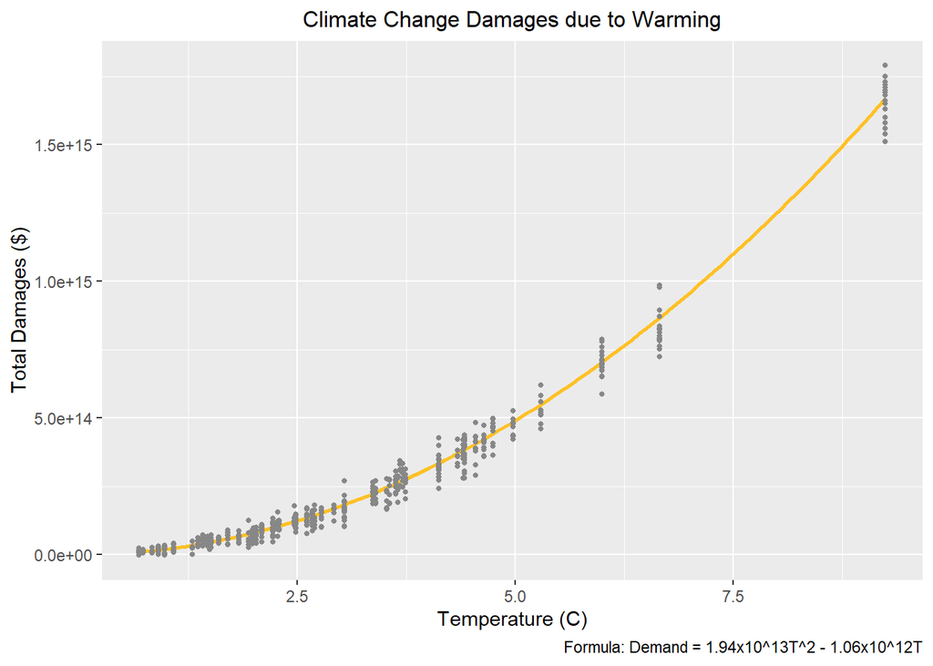

```r
# Data is quadratic - create a vector of damages ans warming (w/ warming squared)

damages_warming_sq <- damages$warming^2

# Run quadratic regression relating damages to warming with a zero intercept
damages_qm <- lm(damages ~ 0 +  warming + damages_warming_sq, data = damages)

# Extract the equation of the line
#extract_eq(model = damages_qm, use_coefs = TRUE, coef_digits = 4)


# Equation of the line for total damages as function of warming (temperature)
# Damages = 1.9x10^13T^2 - 1.06x10^12T
model_damages <- function(x){damages_qm$coefficients[2]*x^2 - damages_qm$coefficients[1]*x}

# The above values are:
#damages_qm$coefficients[1]
# -1059530137756.23
#damages_qm$coefficients[2]
# 19409275730643.3

# Plot damages as function of warming (using quadratic regression model)
#    - include scatterplot of underlying data
ggplot(data = damages, aes(x = warming, y = damages)) +
  stat_function(fun = model_damages, color = "goldenrod1", size = 1) +
  geom_point(size = 1, color = "grey53") +
  labs(x = "Temperature (C)",
       y = "Total Damages ($)",
       title = "Climate Change Damages due to Warming",
       caption = "Formula: Demand = 1.94x10^13T^2 - 1.06x10^12T") +
  theme_grey()+
    theme(plot.title = element_text(hjust = 0.5, size = 12))
```

**Figure 1**: Quadratic regression fitted to cost of environmental damages as a function of warming. The equation is:
$$\ D = 1.941 \times 10^{13} T ^ 2 - 1.060 \times 10^{12} T$$

## Question 2

Use warming.csv and your estimated damage function to predict damages in each year under the baseline climate and the pulse scenario. Make four plots: (1) damages over time without the pulse, (2) damages over time with the pulse, (3) the difference in damages over time that arises from the pulse, and (4) the difference in damages over time from the pulse per ton of CO2 (you can assume that each ton of the pulse causes the same amount of damage).

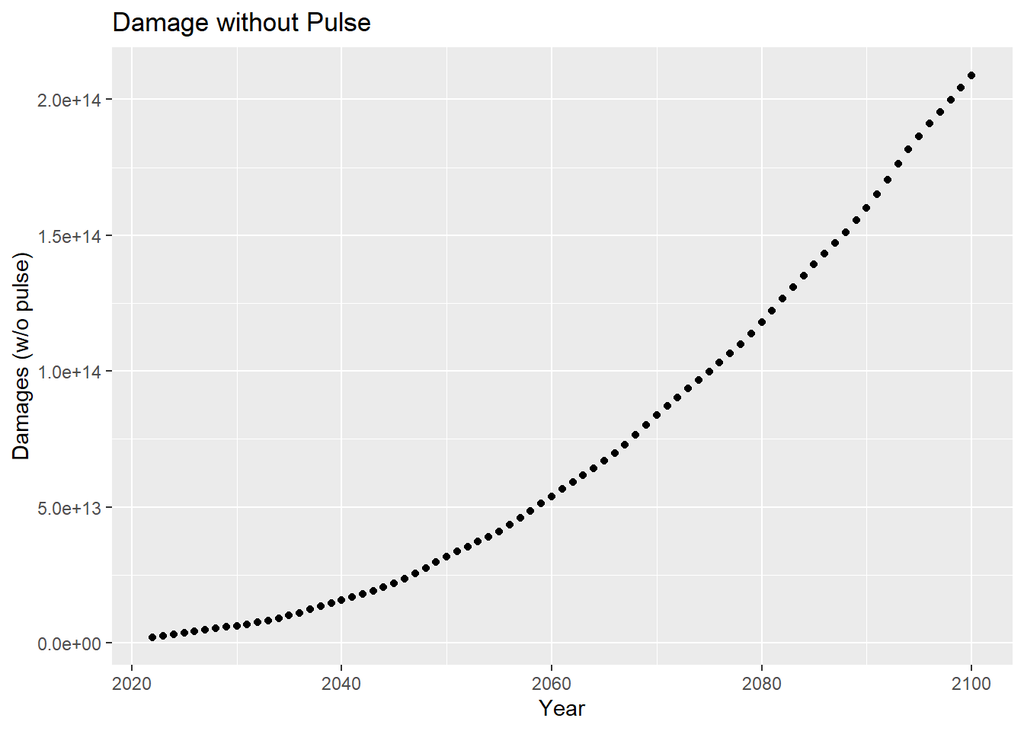

```r
# Add columns to warming dataset calculating each of the scenarios:

# damages over time w/o pulse
warming$warming_no_pulse <- model_damages(warming$warming_baseline)

# damages over time w/ pulse
warming$warming_w_pulse <- model_damages(warming$warming_pulse)

# difference in damages over time that arise from the pulse
warming$difference <- warming$warming_w_pulse - warming$warming_no_pulse

# difference in damages over time from the pulse per ton of CO2
warming$difference_per_ton <- warming$difference/35000000000

# Plot the above

# damage/time w/o pulse
ggplot(data = warming)+
  geom_point(aes(x = year, y = warming_no_pulse)) +
  labs(x = "Year",
       y = "Damages (w/o pulse)",
       title = "Damage without Pulse")+
  theme_grey()
```

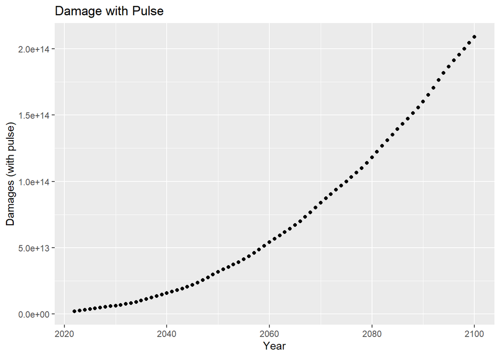

```r
# damage/time w/ pulse
ggplot(data = warming) +
  geom_point(aes(x = year, y = warming_w_pulse)) +
  labs(x = "Year",
       y = "Damages (with pulse)",
       title = "Damage with Pulse")+
  theme_grey()
```

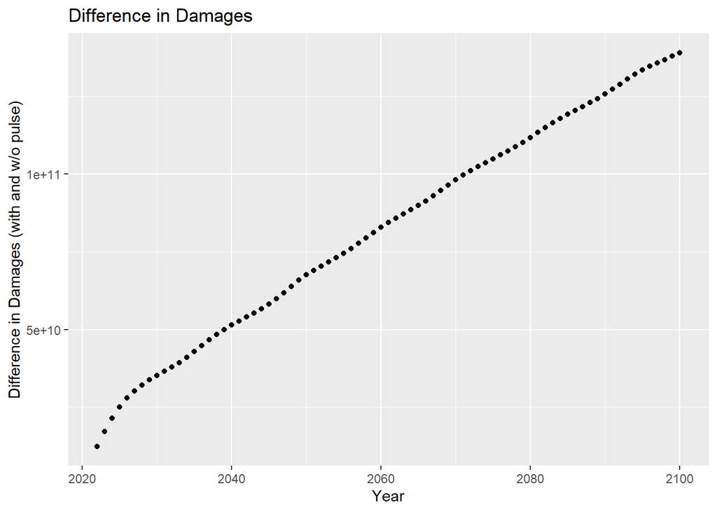

```r
# difference in damage/time due to pulse
ggplot(data = warming) +
  geom_point(aes(x = year, y = difference)) +
  labs(x = "Year",
       y = "Difference in Damages (with and w/o pulse)",
       title = "Difference in Damages")+
  theme_grey()
```

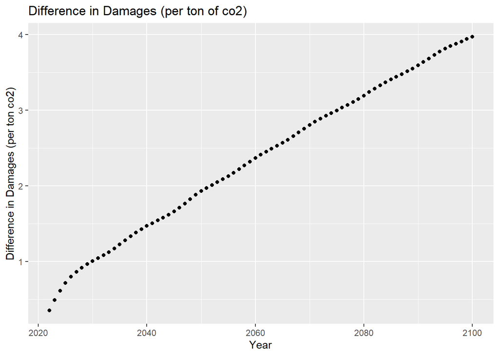

```r
# difference in damage/time due to pulse per ton of co2
ggplot(data = warming) +
  geom_point(aes(x = year, y = difference_per_ton)) +
  labs(x = "Year",
       y = "Difference in Damages (per ton co2)",
       title = "Difference in Damages (per ton of co2)")+
  theme_grey()
```

## Question 3

The SCC is the present discounted value of the stream of future damages caused by one additional ton of CO2. The Obama Administration used a discount rate of 3% to discount damages. Recently, New York State used a discount rate of 2%. Calculate and make a plot of the SCC (y-axis) against the discount rate (x-axis) for a reasonable range of discount rates. Explain the intuition for how the discount rate affects the SCC.

The formula to find the present discounted value of damages due to 1 ton of carbon dioxide up to the year 2100 is:

$$Present Value = \sum_{t = 0}^{78}{\frac{D_t}{(1+r)^t}}$$

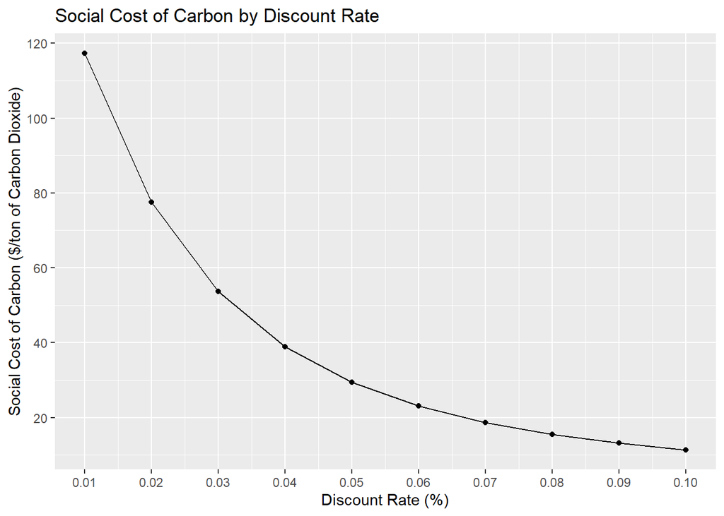

```r
# Add up the damages due to diff per ton of co2 to find total damages from 2022 to 2100 (78 years)
total_damages_per_ton <- sum(warming$difference_per_ton)

# Make a function to calculate NPV
NPV <- function(x) {total_damages_per_ton[1:78]/((1+x)^(1:78))}

# make a df for damages by each discount rate from 0.01 to 1.0
damages_by_scc <- warming %>%
  select(year, difference_per_ton) %>%
  mutate(t_future = year-2022) %>%
  mutate(present_value_01 = difference_per_ton / ((1 + 0.01) ^ t_future)) %>%
  mutate(present_value_02 = difference_per_ton / ((1 + 0.02) ^ t_future)) %>%
  mutate(present_value_03 = difference_per_ton / ((1 + 0.03) ^ t_future))%>%
  mutate(present_value_04 = difference_per_ton / ((1 + 0.04) ^ t_future)) %>%
  mutate(present_value_05 = difference_per_ton / ((1 + 0.05) ^ t_future)) %>%
  mutate(present_value_06 = difference_per_ton / ((1 + 0.06) ^ t_future)) %>%
  mutate(present_value_07 = difference_per_ton / ((1 + 0.07) ^ t_future)) %>%
  mutate(present_value_08 = difference_per_ton / ((1 + 0.08) ^ t_future)) %>%
  mutate(present_value_09 = difference_per_ton / ((1 + 0.09) ^ t_future)) %>%
  mutate(present_value_1 = difference_per_ton / ((1 + 0.10) ^ t_future))


# Sum the present values by disc rate from 2022 to 2100
sum_pv_01 <- sum(damages_by_scc$present_value_01[1:79])
sum_pv_02 <- sum(damages_by_scc$present_value_02[1:79])
sum_pv_03 <- sum(damages_by_scc$present_value_03[1:79])
sum_pv_04 <- sum(damages_by_scc$present_value_04[1:79])
sum_pv_05 <- sum(damages_by_scc$present_value_05[1:79])
sum_pv_06 <- sum(damages_by_scc$present_value_06[1:79])
sum_pv_07 <- sum(damages_by_scc$present_value_07[1:79])
sum_pv_08 <- sum(damages_by_scc$present_value_08[1:79])
sum_pv_09 <- sum(damages_by_scc$present_value_09[1:79])
sum_pv_1 <- sum(damages_by_scc$present_value_1[1:79])

# Create list of all present values (calc above)
sum_pv_vector <- c(sum_pv_01, sum_pv_02, sum_pv_03, sum_pv_04, sum_pv_05, sum_pv_06, sum_pv_07, sum_pv_08, sum_pv_09, sum_pv_1)

# Create a list of the discount rates used above (0.01 to 0.10)
disc_rate_vector <- c(0.01, 0.02, 0.03, 0.04, 0.05, 0.06, 0.07, 0.08, 0.09, 0.10)

# Create df with summed present values and discount rates then plot the values
pv_disc_rate <- data.frame(sum_pv_vector, disc_rate_vector)

# Plot SCC by discount rates ranging from 1 to 10%
ggplot(data = pv_disc_rate, aes(x = disc_rate_vector, y = sum_pv_vector)) +
  geom_point() +
  geom_line() +
  scale_x_continuous(n.breaks = 10) +
  scale_y_continuous(n.breaks = 8) +
  labs(x = "Discount Rate (%)",
       y = "Social Cost of Carbon ($/ton of Carbon Dioxide)",
       title = "Social Cost of Carbon by Discount Rate") +
  theme_grey()
```

```r
#  Calculate and make a plot of the SCC (y-axis) against the discount rate (x-axis) for a reasonable range of discount rates.
#

# Explain the intuition for how the discount rate affects the SCC.
```

**Figure 6**: Shows the SCC at discount rate values ranging from 1% to 10%. This indicates that, SCC decreases as discount rate increases meaning money is valued more in the present than in the future and impacts in the future are not valued as much.

## Question 4

The National Academies of Sciences, Engineering, and Medicine advised the government in a 2017 report to use the Ramsey Rule when discounting within the SCC calculation:

$$r=p+ng$$

Using ρ = 0.001, η = 2, and g = 0.01, what is the SCC? Locate this point on your graph from above.

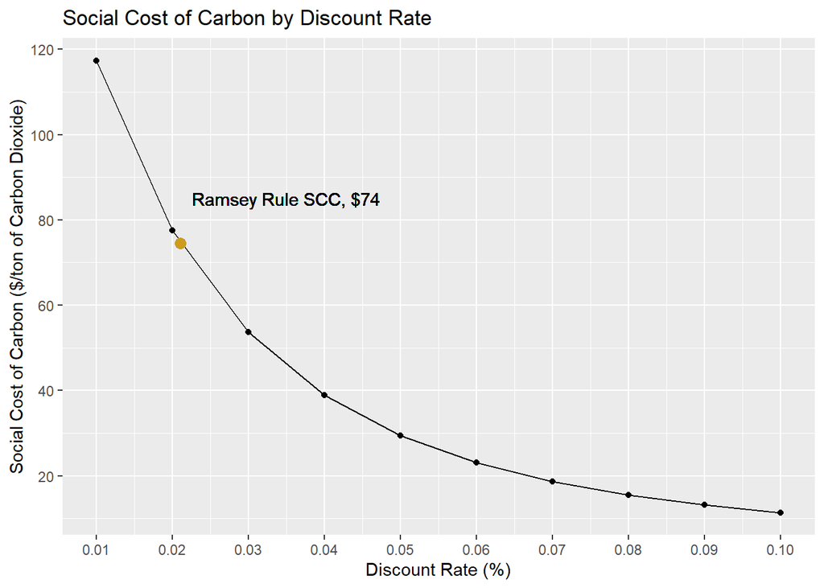

```r
# find disc rate using ramsey rule with the values above
ramsey_disc_rate <- (0.001 + 2*0.01)*100
      # discount rate with ramsey rule is 2.1%


# make a new dataset with present values using rr discount rate of 2.1% (do the same calculations as question 3 but using discount rate of 2.1%)

damages_rr <- warming %>%
  select(year, difference_per_ton) %>%
  mutate(t_future = year-2022) %>%
  mutate(present_value_rr = difference_per_ton / ((1 + ramsey_disc_rate/100) ^ t_future))

# sum present value for 2022 to 2100 under rr discount rate
# sums to $74.57
# add this point to the plot from above
sum_pv_rr <- sum(damages_rr$present_value_rr[1:79])


# copy and pasted plot, add label for rr point
ggplot(data = pv_disc_rate, aes(x = disc_rate_vector, y = sum_pv_vector)) +
  geom_point() +
  geom_line() +
  scale_x_continuous(n.breaks = 10) +
  scale_y_continuous(n.breaks = 8) +
  geom_point(aes(x = 0.021, y = 74.57), color = "goldenrod3", size = 3) +
  geom_text(aes(x = 0.035, y = 85, label = "Ramsey Rule SCC, $74")) +
  labs(x = "Discount Rate (%)",
       y = "Social Cost of Carbon ($/ton of Carbon Dioxide)",
       title = "Social Cost of Carbon by Discount Rate") +
  theme_grey()
```

## Question 5

Now suppose there are two possible climate policies that can be pursued. Policy A is business as usual and Policy B is to take immediate and strong action on climate change. Use these facts:

- If you undertake Policy A there are two possible outcomes. Either warming will occur as in the “baseline” (i.e. “no-pulse”) dataset above (this happens with probability 0.5) or warming each year will be 1.5 times that in the “baseline” dataset (with probability 0.5).
- Under Policy B, warming will continue until 2050 as in the “baseline” dataset, and then will stabilize at 1.29 degrees and stay that way forever.
- Society is risk neutral
- Use a discount rate of 2%

What is the expected present value of damages up to 2100 under Policy A? What is the expected present value of damages up to 2100 under Policy B? Suppose undertaking Policy A costs zero and undertaking Policy B costs X. The total cost of a policy is the implementation cost plus expected damages. Make a plot of total cost of Policy A and total cost of Policy B against X. Suppose Congress wants to undertake the policy with the lower total cost. Use your graph to advise Congress.

```r
# POLICY A
# Create dataset for policy a with npv and damages of both scenarios

# First create a function of net present value
pv_function <- function(rate, damage, time, present_time)
  {NPV <- damage/ (1 + (rate))^(time-present_time)
  return(NPV)}

policy_a <- warming %>%
  select(year, warming_baseline, warming_no_pulse) %>%
  # calc pv for baseline
  mutate(pv_baseline = pv_function(0.02, warming_no_pulse, year, 2022)) %>%

  # calc damages for 1.5x warming
  mutate(damages_1.5x_warming = model_damages(1.5*warming_baseline)) %>%

  # calc pv for 1.5x warming
  mutate(pv_1.5x_warming = pv_function(0.02, damages_1.5x_warming, year, 2022))

# sum pv for each option in policy a
sum_baseline <- sum(policy_a$pv_baseline)
sum_1.5x_warming <- sum(policy_a$pv_1.5x_warming)

total_policy_a <- sum_baseline*0.5 + sum_1.5x_warming*0.5
```

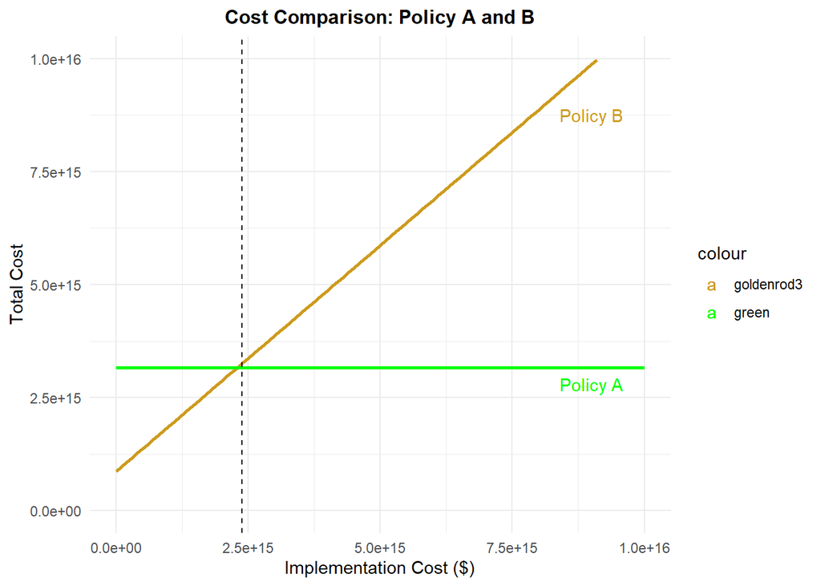

```r
# POLICY B, repeat above process
# warming continues at baseline level until 2050 then stabilizes at 1.29 degrees and stays that way forever

policy_b <- warming %>%
  select(year, warming_baseline)

  # lock warming at 1.29 degrees starting at year 2050
for (i in 30:79){
  policy_b$warming_baseline[i]=1.29
  }

policy_b <- policy_b %>%

  # calc damages w this policy
  mutate(policy_b_damages = model_damages(warming_baseline)) %>%
  mutate(pv_policy_b = pv_function(0.02, policy_b_damages, warming$year, 2022))

total_policy_b <- sum(policy_b$pv_policy_b)*1



#Plot policy a and b costs

#write functions to find the cost of implementing each policy
policy_b_model <- function(x){total_policy_b +x}
policy_a_model <- function(x){total_policy_a}

# make a vector of potential costs

difference <- total_policy_a - total_policy_b

ggplot() +
  scale_color_manual(values = c('goldenrod3', 'green')) +
  stat_function(fun = policy_b_model, color = 'goldenrod3', size = 1) +
  stat_function(fun = policy_a_model, color = 'green', size = 1) +
  ylim(0, 10e+15) +
  xlim(0, 10e+15) +
  labs(x = "Implementation Cost ($)",
       y = "Total Cost",
       title = "Cost Comparison: Policy A and B") +
   geom_text(aes(x = 9.0e+15, y = 8.75e+15, label = "Policy B", color = 'goldenrod3'))+
  geom_text(aes(x = 9.0e+15, y = 2.8e+15, label = "Policy A", color = 'green')) +
  geom_vline(xintercept = 2.38e+15, linetype = "dashed", size = 0.5)+
  theme_minimal() +
  theme(plot.title = element_text(hjust = 0.5, size = 12, face = "bold"))
```

Policy B is recommended if implementation cost is less than ~$2,380 trillion billion dollars. If the cost exceeds ~$2,380 trillion dollars (see dashed line), Policy A is recommended. This recommendation is based on minimizing costs and given that the total cost of Policy A is the present value of damages through 2100 and total cost of Policy B is the sum of the implementation cost and the present value of those damages through 2100.

## Question 6

Now suppose that society is risk averse. How do you think this would change your advice to Congress?

**Policy B is more attractive in a society that is risk averse.**

The utility function for the risk averse society would need to be provided for exact calculations. The general logic for favoring Policy B is rooted in the concave utility function of a risk averse society. Due to the uncertainty of costs for Policy A versus the known costs of policy B given a society averse to risk, Policy B would be recommended.